# Line chart with labels

2025-12-02

Before you run the notebook, make sure the following packages are installed. Use install.packages(‘gapminder’) to install the gapminder package for example. It’s best to do this in the console (bottom-left pane in Posit) rather than in your notebook.

This is a minimal working example of the line chart with labels at the ends. The basic chart code is actually quite simple - the idea is to make 3 separate datasets: 1) the categories you want to highlight (in my example, countries), 2) the data for all the other countries and 3) a dataset of only the last data point for each of the highlighted countries. Then using the function geom_text_repel() from the ggrepel package, plus some adjustments to the borders of the plot, you can quite easily make it.

First load the libraries (install them if you need, first):

```r
library(tidyverse)
library(gapminder) # this contains the dataset I'll use
```

```r
library(ggrepel) # the package to draw text in the correct place
```

Now load the gapminder dataset and call it an object gapminder_df:

```r
gapminder_df <- gapminder
```

Make the separate dataframes (I picked the highlighted countries just because they are spread out across the y axis)

```r
highlighted <- gapminder_df |>
  filter(country %in% c('Netherlands', 'Bolivia',"China", "Botswana"))

others = gapminder_df |>
  filter(!country %in% c('Netherlands', 'Bolivia',"China", "Botswana")) # note the ! to invert the filter

last = highlighted |>
  group_by(country) |>
  slice_max(order_by = year, n = 1) # the group_by and slice_max takes the highest value for each group (country)
```

Make the basic plot - everything else is purely aesthetic.

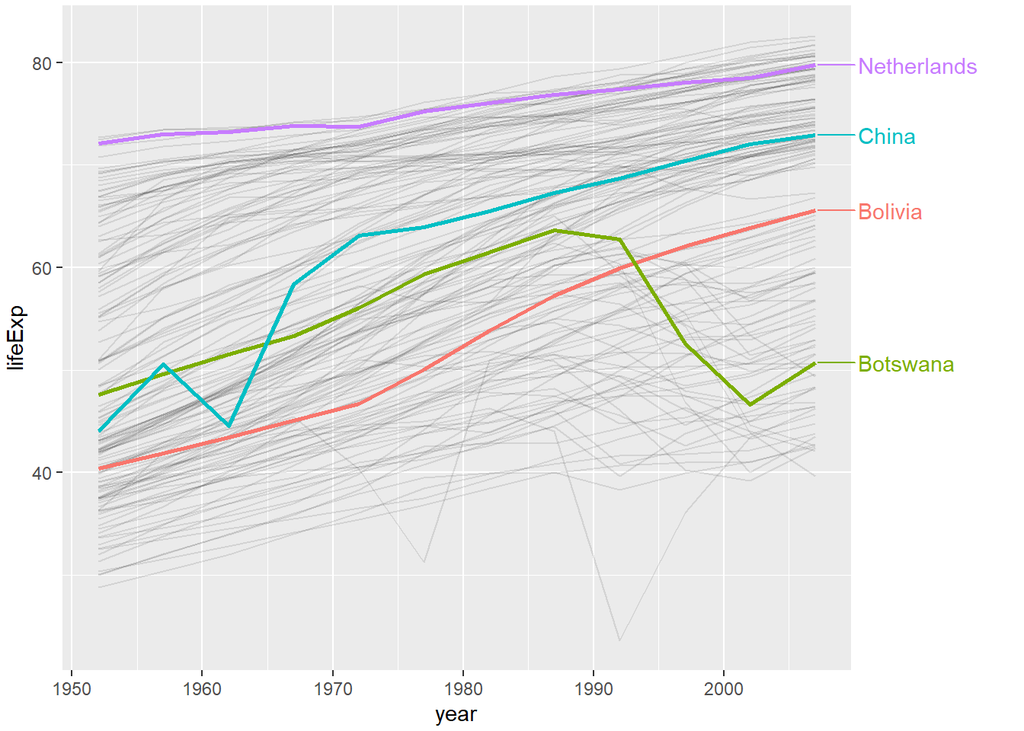

```r
ggplot() +
  geom_line(data = others, aes(x = year, y = lifeExp, group = country), alpha = .1) + # plot all the other lines first and reduce the transparency
  geom_line(data = highlighted, aes(x = year, y = lifeExp, color = country, group = country), size = 1) + # plot the highlighted lines and color them
  geom_text_repel(data = last,
                  aes(x = year, y = lifeExp, color = country, group = country, label = country),
                  xlim = c(2025, NA), # this is the only necessary option in geom_text_repel. It moves the text to the year 2025, which is outside the plot.
  ) +
  theme(legend.position = 'none' ,
            plot.margin = margin(0.1, 3, 0.1, 0.1, "cm"))+ # this plot.margin option is important - it extends the area of the plot beyond the lines.
  coord_cartesian(clip = "off") # This is also important, it means that stuff outside of the plot area will still be drawn.
```

Here is the version with all the added aesthetic changes, and an explanation of what they do:

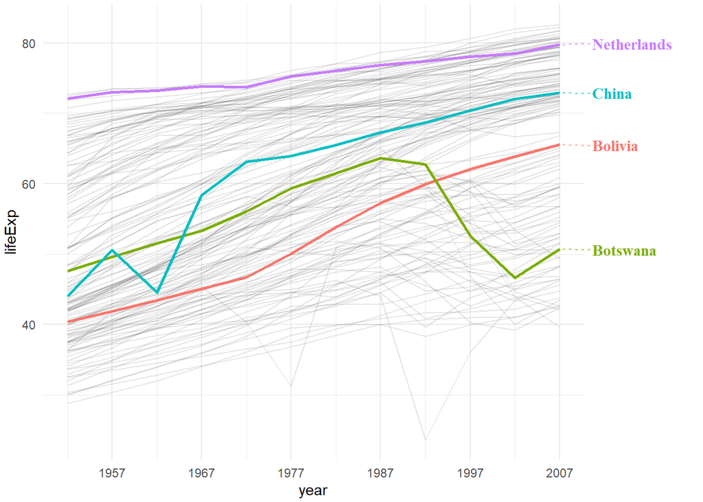

```r
ggplot() +
  geom_line(data = others, aes(x = year, y = lifeExp, group = country), alpha = .1) +
  geom_line(data = highlighted, aes(x = year, y = lifeExp, color = country, group = country), size = 1) +
  geom_text_repel(data = last,
                  aes(x = year, y = lifeExp, color = country, group = country, label = country),
                  xlim = c(2025, NA),
                  family = "serif", # this changes the font. Fonts are a bit complicated because they need to be installed. This is one of the defaults.
                  fontface = "bold", # changes to bold text.
                  size = 4, # adjust the size of the text
                  direction = "y", # specifies that if there is overlap, the algorithm should only adjust the text on the y axis
                  segment.size = .6, # the thickness of the connecting line from the text to the plot end
                  segment.alpha = .5, # the transparency of the connecting line
                  segment.linetype = "dotted", # makes the line dotted.
                  box.padding = .4, # how much space should be kept around each piece of text
                  segment.curvature = -0.1, # if the connecting line needs to curve, how much is that curve
                  segment.ncp = 3, # nothing important, a very specific option to do with curved lines.
                  segment.angle = 180 # also not really doing anything here.
  ) + theme_minimal() +
   theme(legend.position = 'none' ,
            plot.margin = margin(0.1, 3, 0.1, 0.1, "cm"))+
  coord_cartesian(clip = "off") + scale_x_continuous(limits = c(1952,2007), breaks = c(1957, 1967, 1977, 1987, 1997, 2007)) # adjusting the scale limits and breaks to make it a bit neater.
```